# Introduction to plotting with ggplot in R

6/23/2019

## Why vizualize data?

1. To explore relationships in our data
2. To communicate/present what we found

[figure not shown]

## Why ggplot?

- Easy to quickly generate plots which can help us do # 1
- Flexible and good defaults which help us with # 2

## Packages we need

```r
# install.packages("ggplot2")
# install.packages("tidyverse")
library(ggplot2)
```

## The basics of the ggplot = the dataframe

- Classic R dataset

```r
head(iris)
```

```
##   Sepal.Length Sepal.Width Petal.Length Petal.Width Species
## 1          5.1         3.5          1.4         0.2  setosa
## 2          4.9         3.0          1.4         0.2  setosa
## 3          4.7         3.2          1.3         0.2  setosa
## 4          4.6         3.1          1.5         0.2  setosa
## 5          5.0         3.6          1.4         0.2  setosa
## 6          5.4         3.9          1.7         0.4  setosa
```

## The basics of the ggplot = the dataframe

- A dataframe where each row corresponds to a record (‘wide format’) and variables are columns

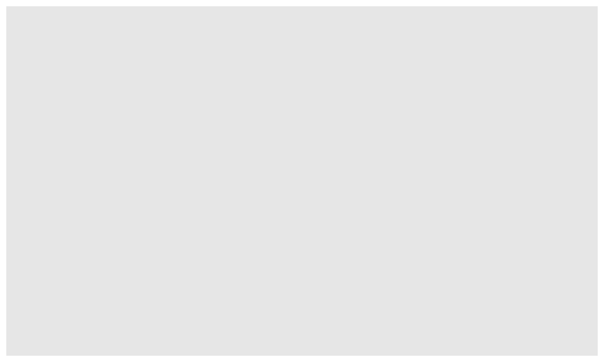

```r
ggplot(data = iris)
```

**Creates a blank plot. We need to decide what variables we want to plot.**

## The basics of the ggplot = the aes

- aes = the aesthetics.

```r
head(iris)
```

```
##   Sepal.Length Sepal.Width Petal.Length Petal.Width Species
## 1          5.1         3.5          1.4         0.2  setosa
## 2          4.9         3.0          1.4         0.2  setosa
## 3          4.7         3.2          1.3         0.2  setosa
## 4          4.6         3.1          1.5         0.2  setosa
## 5          5.0         3.6          1.4         0.2  setosa
## 6          5.4         3.9          1.7         0.4  setosa
```

**Let’s look at the relationship between the variables Sepal.Length and Sepal.Width.**

## The basics of the ggplot = the aes

- aes = the aesthetics (what we want to plot)

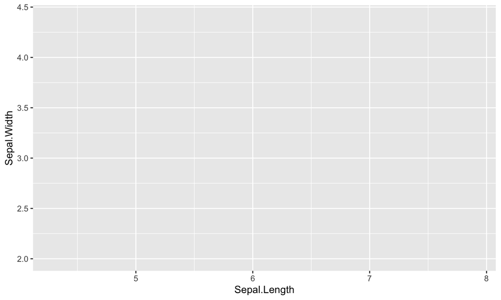

```r
## Let's try the Sepal.Length vs. the Sepal.Width (x, y plot)
ggplot(data = iris, aes(x = Sepal.Length, y = Sepal.Width))
```

**Still blank! We need to decide what kind of plot to use.**

## How do we figure out what kind of plot to use?

**We need to think about how best to visualize this data.**

```r
summary(iris)
```

```
##   Sepal.Length    Sepal.Width     Petal.Length    Petal.Width
##  Min.   :4.300   Min.   :2.000   Min.   :1.000   Min.   :0.100
##  1st Qu.:5.100   1st Qu.:2.800   1st Qu.:1.600   1st Qu.:0.300
##  Median :5.800   Median :3.000   Median :4.350   Median :1.300
##  Mean   :5.843   Mean   :3.057   Mean   :3.758   Mean   :1.199
##  3rd Qu.:6.400   3rd Qu.:3.300   3rd Qu.:5.100   3rd Qu.:1.800
##  Max.   :7.900   Max.   :4.400   Max.   :6.900   Max.   :2.500
##        Species
##  setosa    :50
##  versicolor:50
##  virginica :50
##
##
##
```

## How do we figure out what kind of plot to use?

**We need to think about what we want to show.**

Quick excercise: try drawing with pen and paper what you think these plots might look like:

- Relationship between Sepal.Length and Sepal.Width
- Distribution of Petal.Length
- Comparing the means of Sepal.Length by Species

## How do we figure out what kind of plot to use?

** We need to think about what we want to show.**

Quick excercise: try drawing with pen and paper what you think these plots might look like:

- Relationship between Sepal.Length and Sepal.Width
- Distribution of Petal.Length
- Comparing the means of Sepal.Length by Species

**Hint** Here are the options: Histogram - XY Scatter plot - Boxplot.

## The basics of ggplot = the geom

- Geom = geometry
- The ‘geom_’ functions choose what kind of graph we want to show:
  - **geom_point (point graphs, xy relationships)**
  - **geom_histogram (distribution of a continuous variable)**
  - **geom_boxplot (comparing means of groups)**
  - geom_col/geom_bar
  - geom_line (timeseries)
  - geom_tile (heatmaps)
  - geom_polygon (mapping)

## geom_point: XY Relationship

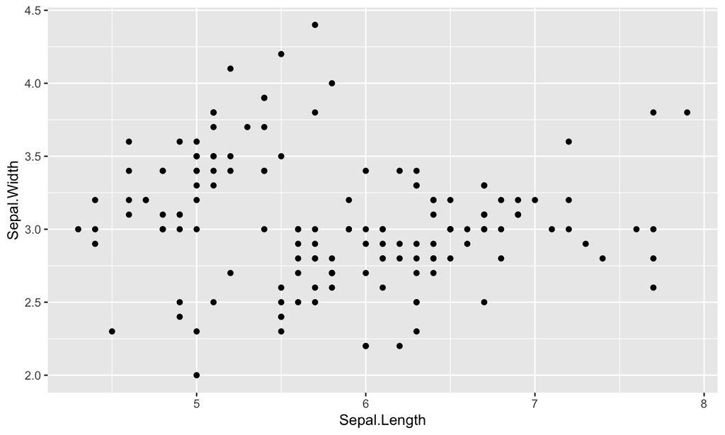

```r
## add the geom that we want
ggplot(data = iris, aes(x = Sepal.Length, y = Sepal.Width)) +
  geom_point()
```

**Is there anything you notice?**

## Adding other aesthetics to help visualize potential relationships

**Using color, we want to differentiate the points by species.**

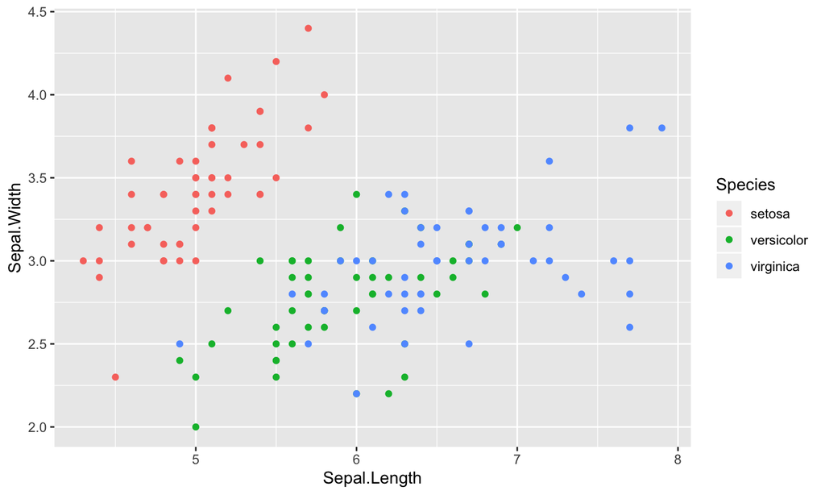

```r
##
ggplot(data = iris, aes(x = Sepal.Length, y = Sepal.Width, color = Species)) +
  geom_point()
```

## Adding other aesthetics to help visualize potential relationships

- The common aesthetics you can add:
  - color
  - fill
  - shape
  - linewidth
  - alpha (transparency)

## Adding other aesthetics to help visualize potential relationships

**Now try it with shape and fill.**

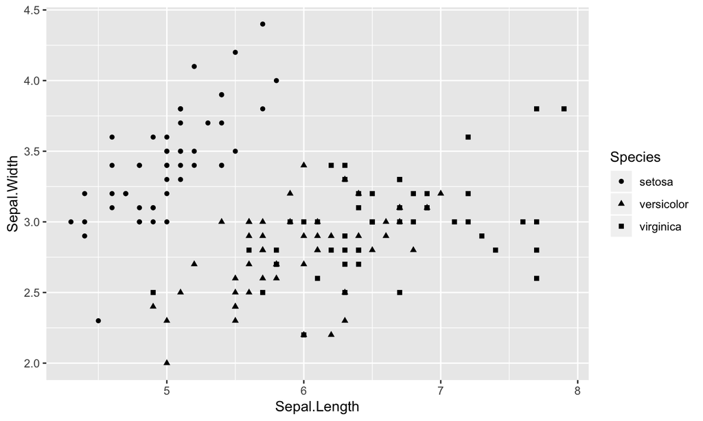

```r
##
ggplot(data = iris, aes(x = Sepal.Length, y = Sepal.Width, shape = Species)) +
  geom_point()
```

**Need to trouble shoot a bit to see what the best option is for a given geom.**

## Specifying things within vs. outside the aes

- Outside aes

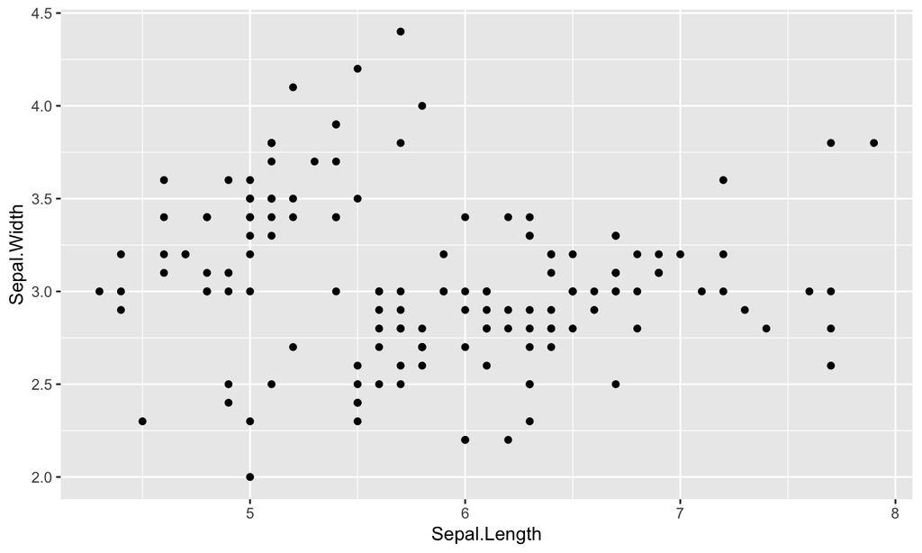

```r
## try it outside
ggplot(data = iris, aes(x = Sepal.Length, y = Sepal.Width), color = Species) +
  geom_point()
```

## Specifying things within vs. outside the aes

- As part of geom

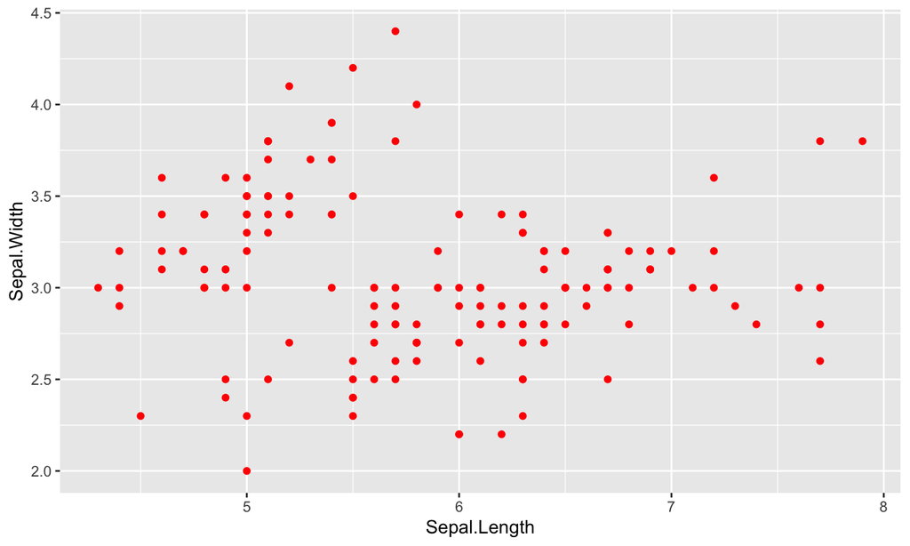

```r
## add it to the geom
ggplot(data = iris, aes(x = Sepal.Length, y = Sepal.Width)) +
  geom_point(color = "red")
```

## Specifying things within vs. outside the aes

- Inside aes = the way to specify an aesthetic by a variable in the dataframe.

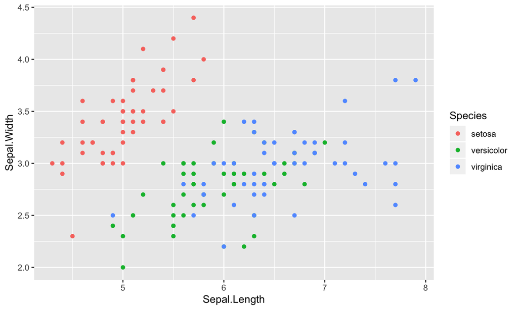

```r
##
ggplot(data = iris, aes(x = Sepal.Length,
                        y = Sepal.Width, color = Species)) +
  geom_point()
```

**Try playing around with the aesthetics and see what you get!**

## Going a bit further: comparing means

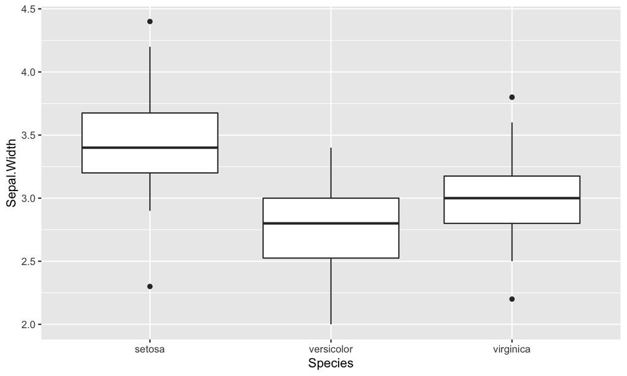

```r
##
ggplot(data = iris, aes(x = Species,
                        y = Sepal.Width)) +
  geom_boxplot()
```

## Going a bit further: distributions

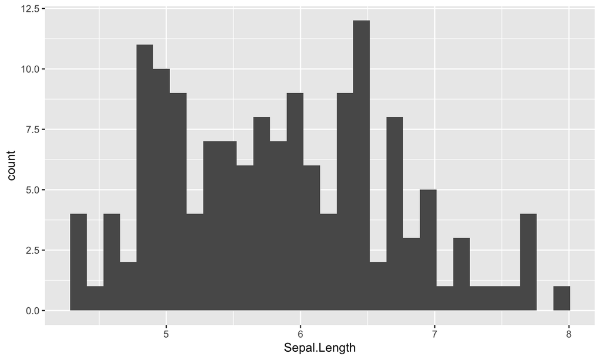

```r
## The histogram
ggplot(data = iris, aes(x = Sepal.Length)) +
  geom_histogram()
```

**Play around with the binwidth option to see what the best bin is**.

## Going a bit further: distributions by categorical variable

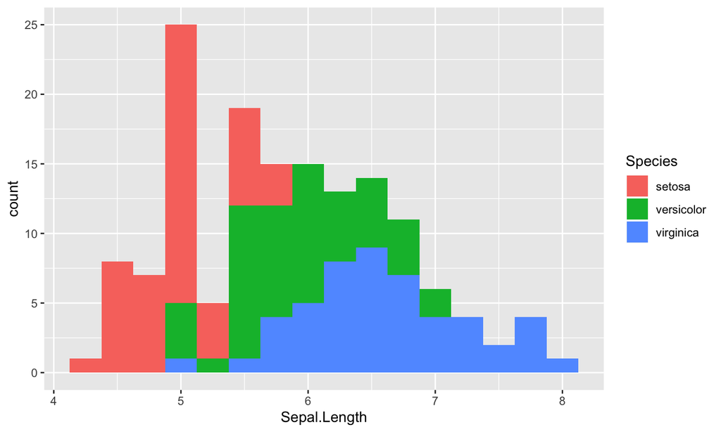

```r
## The histogram
ggplot(data = iris, aes(x = Sepal.Length, fill = Species)) +
    geom_histogram(binwidth = 0.25)
```

## Going a bit further: distributions by categorical variable

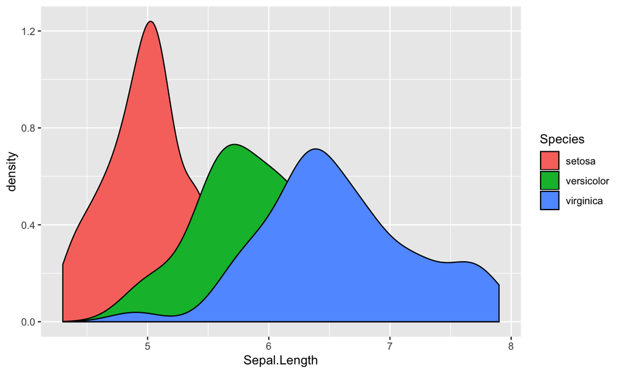

```r
## The density plot
ggplot(data = iris, aes(x = Sepal.Length, fill = Species)) +
  geom_density()
```

## Going a bit further: creating multiple plots with facetting

- If we want to split this plot by species to make it easier to see the distributions

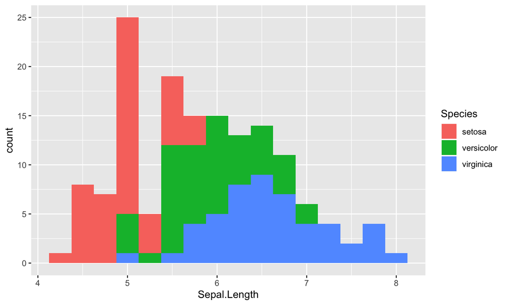

```r
## By fill
ggplot(data = iris, aes(x = Sepal.Length, fill = Species)) +
  geom_histogram(binwidth = 0.25)
```

## Going a bit further: creating multiple plots with facetting

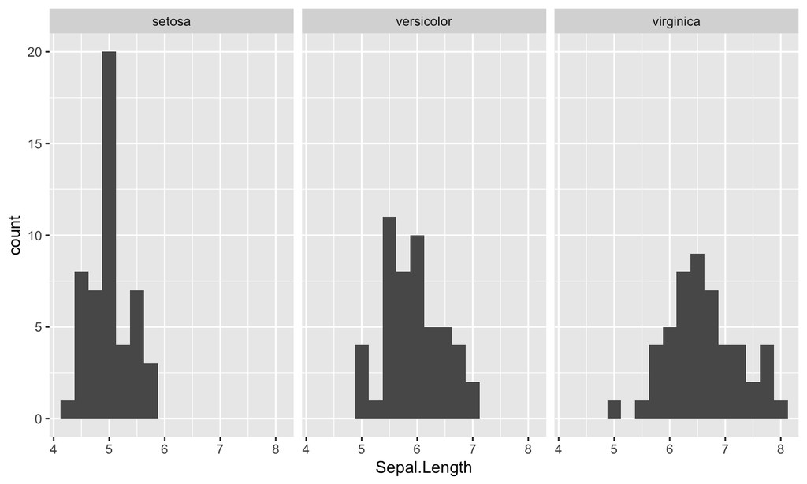

```r
## By facetting
ggplot(data = iris, aes(x = Sepal.Length)) +
  geom_histogram(binwidth = 0.25) +
  facet_wrap(~ Species)
```

## Customizing our ggplot

- We’ll save our ggplot as an object called base.

```r
base <- ggplot(data = iris, aes(x = Species, y = Sepal.Length, color = Species)) +
  geom_boxplot()
```

## Customizing: labels

- Then we can change specific components of it by adding customizations.

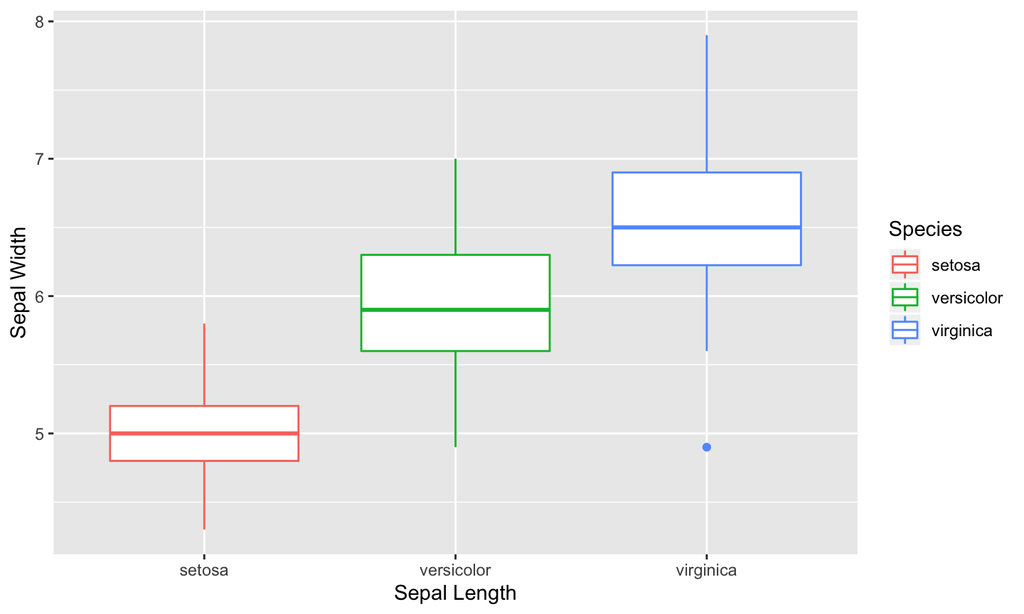

```r
base +
  xlab("Sepal Length") +
  ylab("Sepal Width")
```

## Customizing: color scales

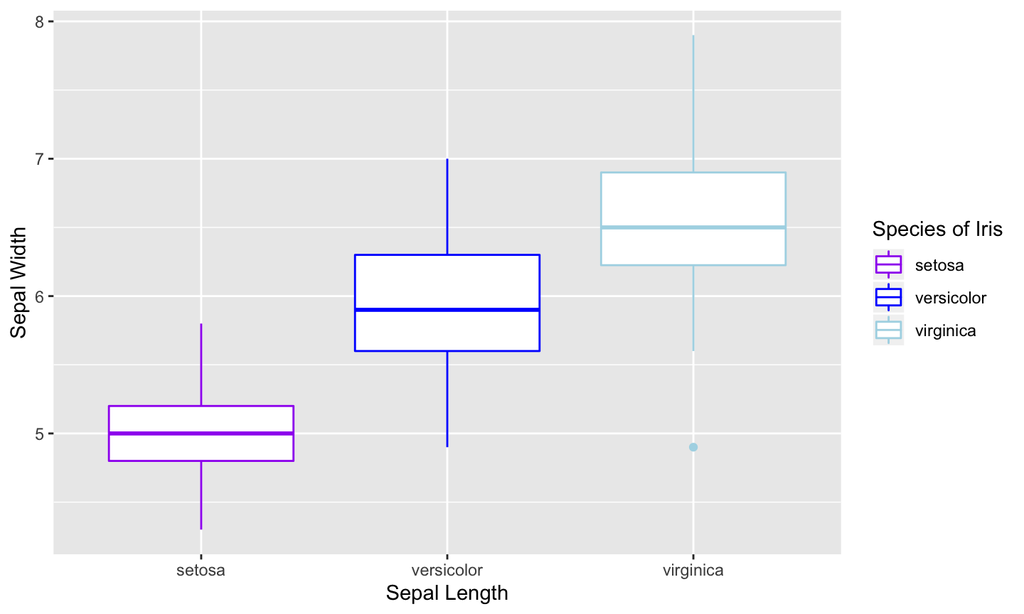

```r
base +
  xlab("Sepal Length") +
  ylab("Sepal Width") +
  scale_color_manual(values = c("purple", "blue", "lightblue"), name = "Species of Iris")
```

## Customizing: color scales

- The scale_ functions help us specify what colors we want to use
  - scale_fill_gradient
  - scale_fill_continuous
- The viridis color scales are a good option to try for continuous variables! (scale_fill_viridis)

## Customizing: themes

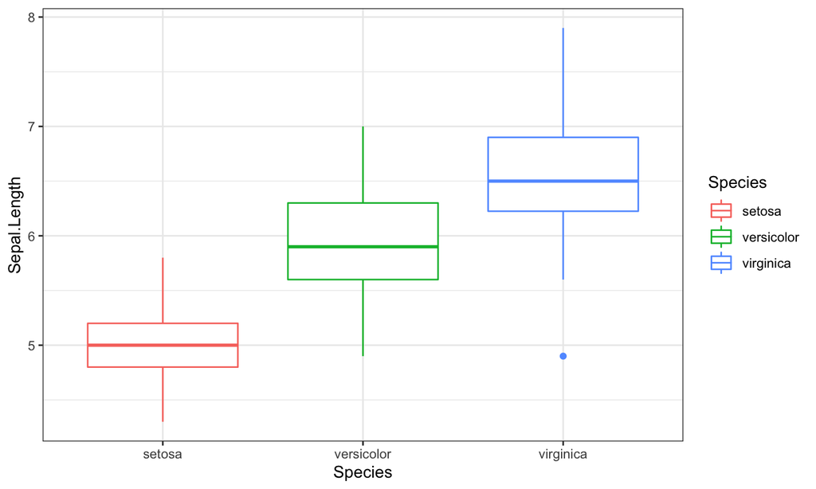

```r
base +
  theme_bw()
```

**Try theme_dark and theme_classic.**

## Saving our plots

```r
base <- ggplot(data = iris, aes(x = Species, y = Sepal.Width, color = Species)) +
  geom_boxplot() +
  xlab("Sepal Length") +
  ylab("Sepal Width") +
  scale_color_manual(values = c("purple", "blue", "pink"), name = "Species of Iris") +
  theme_bw()

ggsave("base_plot.pdf", base, device = "pdf")
```

## Customizing…the options are almost unlimited!

- For most of the routine things you need to do, there is a way. To figure it out your best friend is stack exchange and the ggplot documentation!

## Other considerations: communicating accurately and effectively

- Anscombe’s quartet
  - Identical means, variance, and correlation, but when you plot it you see the differences.

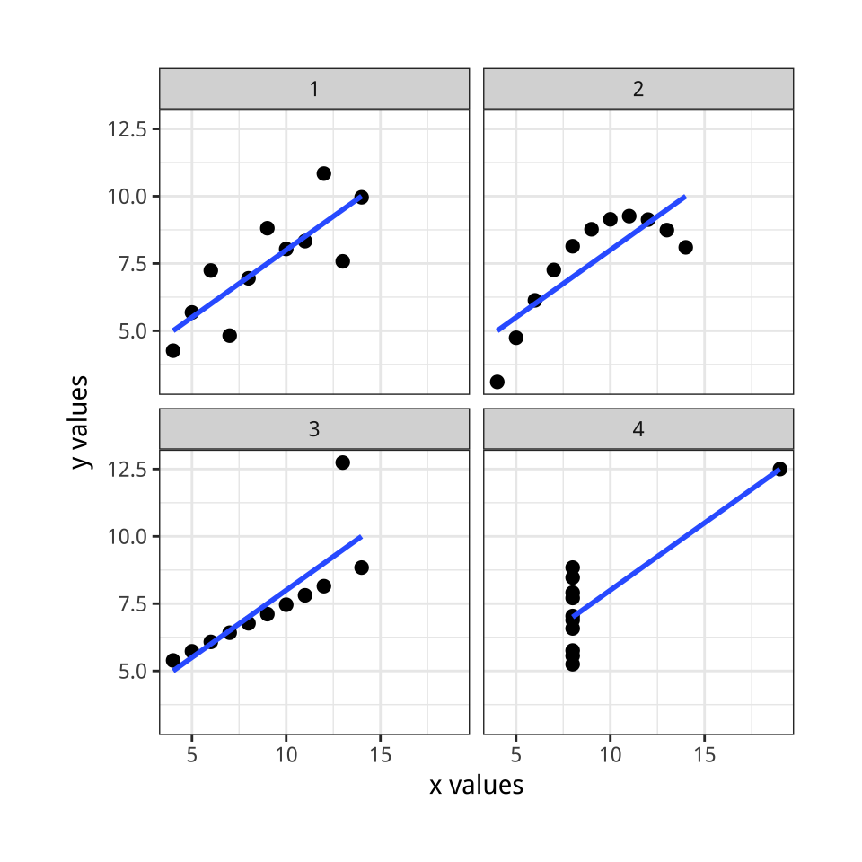

## Other considerations: communicating accurately and effectively

- Scales of axes: should they include zero?

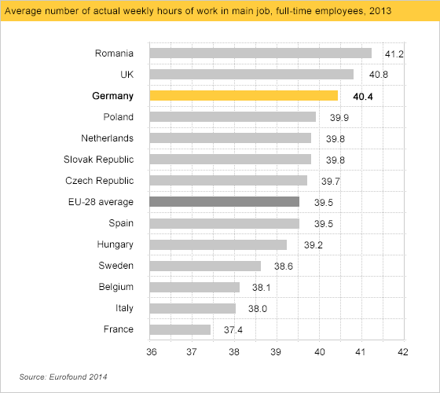

## Other considerations: communicating accurately and effectively

- Scales of axes: should they include zero?

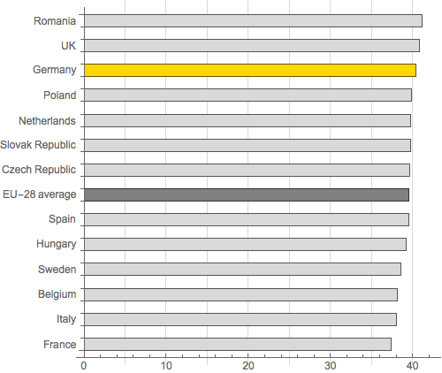

## Other considerations: communicating accurately and effectively

- Scales of axes: should they include zero?

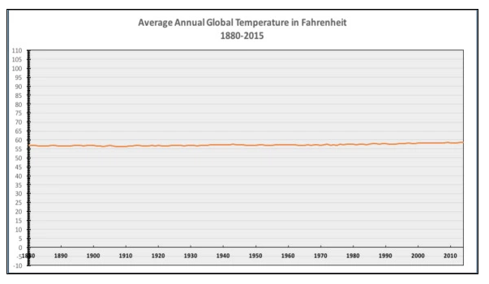

## Other considerations: communicating accurately and effectively

- Scales of axes: should they include zero?

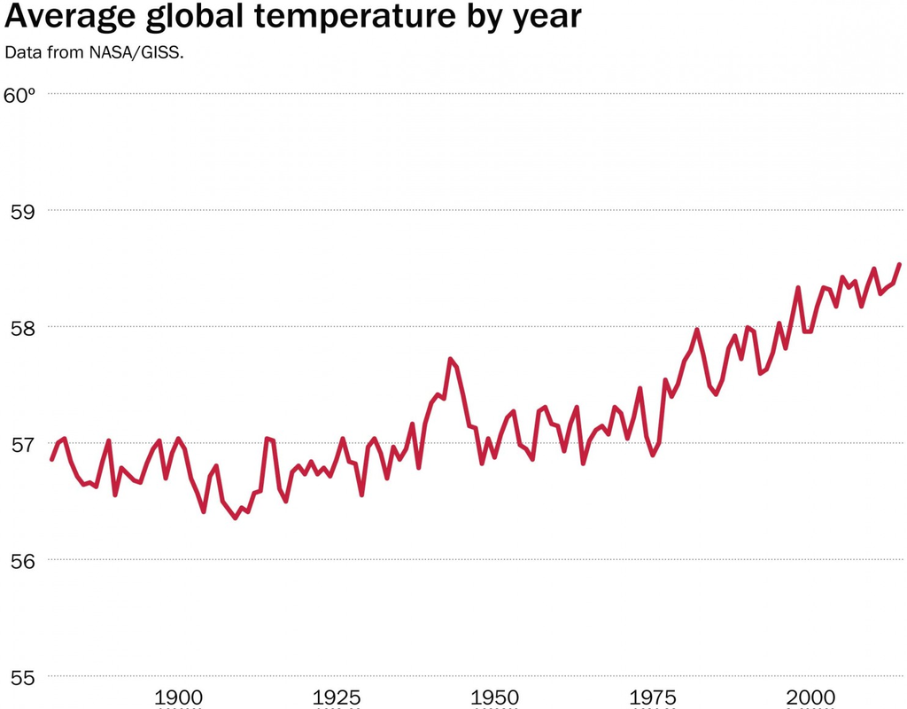

## Excercises

- Using the RxP data, plot:
  - The distribution of Snout-vent length at emergence (SVL.initial)
  - The correlation between Snout-vent length at emergence and at the end of the experiment (SVL.initial and SVL.final)
  - The mean of SVL.final by Res
  - The mean of SVL.final by Pred
  - Advanced: the mean difference between final and initial SVL for Res and Pred

## How would you plot your own data?

## More resources

- General data vizualization: https://flowingdata.com
- Vizualizing data with ggplot2: http://socviz.co
- ggplot cheatsheet: https://www.rstudio.com/wp-content/uploads/2015/03/ggplot2-cheatsheet.pdf
- data carpentry course: https://datacarpentry.org/R-ecology-lesson/04-visualization-ggplot2.html